# Augmenting Paths

Instead of editing the RMarkdown source file for this assignment, you can just draw diagrams on paper and scan them to PDF using a scanning app, or you could produce a PDF file some other way. Upload the `.pdf` to Canvas.

Consider the following flow network $G$. Values of a flow $f$ and edge capacities are given as “value/capacity” pairs.

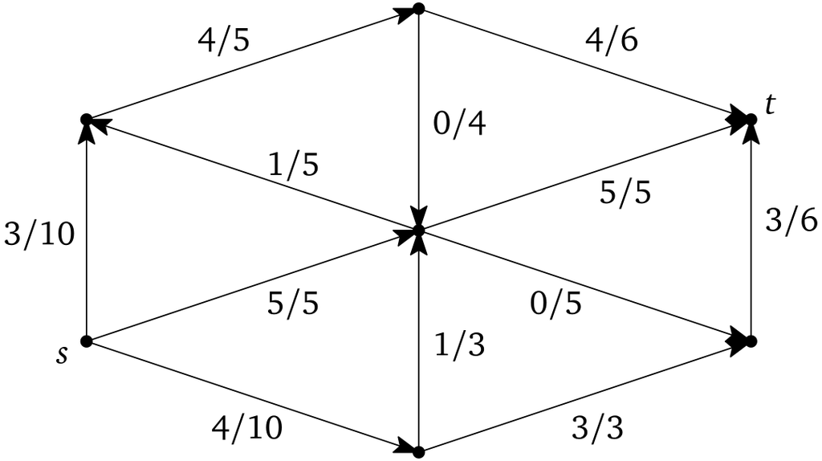

1. Draw the residual graph $G_f$.
2. Find a path from $s$ to $t$ in $G_f$, and determine $F$, the maximum amount of flow through this path. (Choose this path so that $F$ is as large as possible.)
3. Augment the flow $f$ using the augmenting path you found in #2 to obtain a new flow $f'$.
4. Repeat steps 1-3 (update the residual graph, find an augmenting path, augment the flow) as many times as necessary to obtain a maximum flow in $G$.
5. Show that your maximum flow is actually a maximum flow by finding a cut whose capacity equals the total value of the flow.
6. Does your minimum cut correspond to the set of vertices that are reachable from $s$ in the residual graph?